# Logistic Regression, Multi-layer Perceptron Neural Network, Random Forest, XGBoost and PyTorchon Baxter Dataset

#### Let’s make sure we are using the Python version we want

```python
import sys
print(sys.version)
```

```
[Output] 3.6.6 (v3.6.6:4cf1f54eb7, Jun 26 2018, 17:02:57)
[Output] [GCC 4.2.1 (Apple Inc. build 5666) (dot 3)]
```

#### Let’s make sure we are in our project directory

```python
import os
print(os.getcwd())
```

```
[Output] /Users/Begum/Documents/DeepLearning
```

#### Read and prepare data

We will use OTUs for each sample as our features and diagnosis column in the metadata as our classifier. Cancer is 1 and Normal is 0.

```python
## Read in the data
shared = pd.read_table("data/baxter.0.03.subsample.shared")
shared.head()
meta = pd.read_table("data/metadata.tsv")
## Check and visualize the data
print(meta.head())
```

```
[Output]     sample  fit_result        Site    ...    Diabetes_Med stage  Location
[Output] 0  2003650           0  U Michigan    ...               0     0       NaN
[Output] 1  2005650           0  U Michigan    ...               0     0       NaN
[Output] 2  2007660          26  U Michigan    ...               0     0       NaN
[Output] 3  2009650          10     Toronto    ...               0     0       NaN
[Output] 4  2013660           0  U Michigan    ...               0     0       NaN
[Output]
[Output] [5 rows x 27 columns]
```

```python
print(shared.head())
## Remove unnecessary columns from meta
```

```
[Output]    label    Group  numOtus    ...     Otu11278  Otu11280  Otu11281
[Output] 0   0.03  2003650     6920    ...            0         0         0
[Output] 1   0.03  2005650     6920    ...            0         0         0
[Output] 2   0.03  2007660     6920    ...            0         0         0
[Output] 3   0.03  2009650     6920    ...            0         0         0
[Output] 4   0.03  2013660     6920    ...            0         0         0
[Output]
[Output] [5 rows x 6923 columns]
```

```python
meta = meta[['sample','dx']]
## Rename the column name "Group" to match the "sample" in meta
shared = shared.rename(index=str, columns={"Group":"sample"})
## Merge the 2 datasets on sample
data=pd.merge(meta,shared,on=['sample'])
## Remove adenoma samples
data= data[data.dx.str.contains("adenoma") == False]
## Drop all except OTU columns for x
x = data.drop(["sample", "dx", "numOtus", "label"], axis=1)
## Cancer =1 Normal =0
diagnosis = { "cancer":1, "normal":0}
##Generate y which only has diagnosis as 0 and 1
y = data["dx"].replace(diagnosis)
# y = np.eye(2, dtype='uint8')[y]
## Drop if NA elements
y.dropna()
x.dropna()
print(x.head())
```

```
[Output]    Otu00001  Otu00002  Otu00003    ...     Otu11278  Otu11280  Otu11281
[Output] 0       350       268       213    ...            0         0         0
[Output] 1       568      1320        13    ...            0         0         0
[Output] 2       151       756       802    ...            0         0         0
[Output] 4      1409       174         0    ...            0         0         0
[Output] 5       167       712       213    ...            0         0         0
[Output]
[Output] [5 rows x 6920 columns]
```

```python
print(y.head())
```

```
[Output] 0    0
[Output] 1    0
[Output] 2    0
[Output] 4    0
[Output] 5    0
[Output] Name: dx, dtype: int64
```

```python
print(len(x))
```

```
[Output] 292
```

```python
print(len(y))
```

```
[Output] 292
```

#### Now let’s define a L2 regularized logistic regression model

```python
## Define L2 regularized logistic classifier
logreg = linear_model.LogisticRegression(C=0.01)
```

#### Plot ROC curve for Logistic Regression model on training set and predict test set

We split training and test set 80-20%. We further split the training set to 5 to cross-validate in a loop. We predict test set in the same loop. We generate mean AUC for cross-validation with training set upon 50 epochs and mean AUC for test set upon 50 epochs.

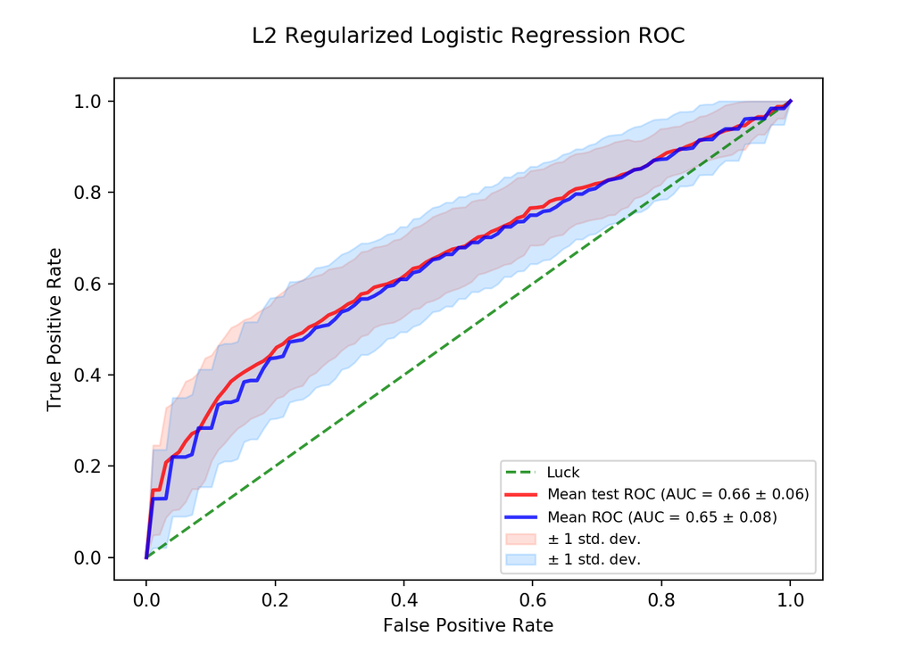

```python
cv = StratifiedKFold(n_splits=5)
tprs = []
aucs = []
mean_fpr = np.linspace(0, 1, 100)
tprs_test = []
aucs_test = []
mean_fpr_test = np.linspace(0, 1, 100)
# Plot the ROC curve over 10 iterations for each split
Logit_plot = plt.figure()
epochs = 50
for epoch in range(epochs):
    x_train, x_test, y_train, y_test = train_test_split(x, y, test_size=0.2, shuffle=True)
    X=x_train.values
    Y=y_train.values
    X_test= x_test.values
    Y_test= y_test.values
    i = 0
    for train, test in cv.split(X,Y):
        probas_ = logreg.fit(X[train], Y[train]).predict_proba(X[test])
    # Compute ROC curve and area the curve
        fpr, tpr, thresholds = roc_curve(Y[test], probas_[:, 1])
        tprs.append(interp(mean_fpr, fpr, tpr))
        tprs[-1][0] = 0.0
        roc_auc = auc(fpr, tpr)
        aucs.append(roc_auc)
        #plt.plot(fpr, tpr, lw=1, alpha=0.3, label='Epoch %d, ROC fold %d (AUC = %0.2f)' % (epoch, i, roc_auc))
        #i += 1
    probas_ = logreg.predict_proba(X_test)
    # Compute ROC curve and area the curve
    fpr_test, tpr_test, thresholds_test = roc_curve(Y_test, probas_[:, 1])
    tprs_test.append(interp(mean_fpr_test, fpr_test, tpr_test))
    tprs_test[-1][0] = 0.0
    roc_auc_test = auc(fpr_test, tpr_test)
    aucs_test.append(roc_auc_test)
plt.plot([0, 1], [0, 1], linestyle='--', color='green', label='Luck', alpha=.8)
mean_tpr_test = np.mean(tprs_test, axis=0)
mean_tpr_test[-1] = 1.0
mean_auc_test = auc(mean_fpr_test, mean_tpr_test)
std_auc_test = np.std(aucs_test)
plt.plot(mean_fpr_test, mean_tpr_test, color='r', label=r'Mean test ROC (AUC = %0.2f $\pm$ %0.2f)' % (mean_auc_test, std_auc_test), lw=2, alpha=.8)
std_tpr_test = np.std(tprs_test, axis=0)
tprs_upper_test = np.minimum(mean_tpr_test + std_tpr_test, 1)
tprs_lower_test = np.maximum(mean_tpr_test - std_tpr_test, 0)
plt.fill_between(mean_fpr_test, tprs_lower_test, tprs_upper_test, color='tomato', alpha=.2, label=r'$\pm$ 1 std. dev.')
mean_tpr = np.mean(tprs, axis=0)
mean_tpr[-1] = 1.0
mean_auc = auc(mean_fpr, mean_tpr)
std_auc = np.std(aucs)
plt.plot(mean_fpr, mean_tpr, color='b', label=r'Mean ROC (AUC = %0.2f $\pm$ %0.2f)' % (mean_auc, std_auc), lw=2, alpha=.8)
std_tpr = np.std(tprs, axis=0)
tprs_upper = np.minimum(mean_tpr + std_tpr, 1)
tprs_lower = np.maximum(mean_tpr - std_tpr, 0)
plt.fill_between(mean_fpr, tprs_lower, tprs_upper, color='dodgerblue', alpha=.2, label=r'$\pm$ 1 std. dev.')
plt.xlim([-0.05, 1.05])
plt.ylim([-0.05, 1.05])
plt.xlabel('False Positive Rate')
plt.ylabel('True Positive Rate')
plt.title('L2 Regularized Logistic Regression ROC\n')
plt.legend(loc="lower right", fontsize=8)
plt.show()
#Logit_plot.savefig('results/figures/Logit_Baxter.png', dpi=1000)
```

#### Now let’s define a Multi-layer Perceptron Neural Network Model

Here the activation function is a logistic regression. There is 1 hidden layer with 100 nodes.

```python
clf = MLPClassifier(activation='logistic', alpha=0.001, batch_size='auto',
       beta_1=0.9, beta_2=0.999, early_stopping=True, epsilon=1e-08,
       hidden_layer_sizes=(100,), learning_rate='adaptive',
       learning_rate_init=0.001, max_iter=200, momentum=0.9,
       nesterovs_momentum=True, power_t=0.5, random_state=1, shuffle=True,
       solver='sgd', tol=0.0001, validation_fraction=0.1, verbose=False,
       warm_start=False)
```

#### Plot ROC curve for MLP on training set

We split training and test set 80-20%. We further split the training set to 5 to cross-validate in a loop. We predict test set in the same loop. We generate mean AUC for cross-validation with training set upon 50 epochs and mean AUC for test set upon 50 epochs.

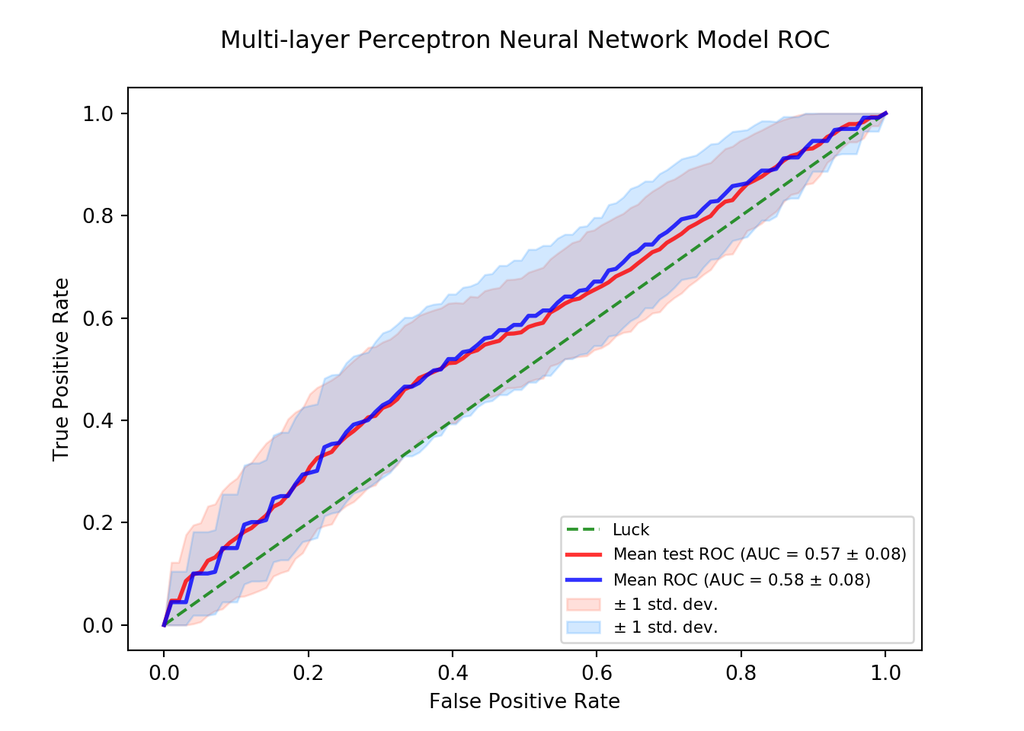

```python
cv = StratifiedKFold(n_splits=5)
tprs = []
aucs = []
mean_fpr = np.linspace(0, 1, 100)
tprs_test = []
aucs_test = []
mean_fpr_test = np.linspace(0, 1, 100)
MLP_plot = plt.figure()
epochs = 50
for epoch in range(epochs):
    x_train, x_test, y_train, y_test = train_test_split(x, y, test_size=0.2, shuffle=True)
    X=x_train.values
    Y=y_train.values
    X_test= x_test.values
    Y_test= y_test.values
    i = 0
    for train, test in cv.split(X,Y):
        probas_ = clf.fit(X[train], Y[train]).predict_proba(X[test])
    # Compute ROC curve and area the curve
        fpr, tpr, thresholds = roc_curve(Y[test], probas_[:, 1])
        tprs.append(interp(mean_fpr, fpr, tpr))
        tprs[-1][0] = 0.0
        roc_auc = auc(fpr, tpr)
        aucs.append(roc_auc)
        #plt.plot(fpr, tpr, lw=1, alpha=0.3, label='Epoch %d, ROC fold %d (AUC = %0.2f)' % (epoch, i, roc_auc))
        #i += 1
    probas_ = clf.predict_proba(X_test)
    # Compute ROC curve and area the curve
    fpr_test, tpr_test, thresholds_test = roc_curve(Y_test, probas_[:, 1])
    tprs_test.append(interp(mean_fpr_test, fpr_test, tpr_test))
    tprs_test[-1][0] = 0.0
    roc_auc_test = auc(fpr_test, tpr_test)
    aucs_test.append(roc_auc_test)
plt.plot([0, 1], [0, 1], linestyle='--', color='green', label='Luck', alpha=.8)
mean_tpr_test = np.mean(tprs_test, axis=0)
mean_tpr_test[-1] = 1.0
mean_auc_test = auc(mean_fpr_test, mean_tpr_test)
std_auc_test = np.std(aucs_test)
plt.plot(mean_fpr_test, mean_tpr_test, color='r', label=r'Mean test ROC (AUC = %0.2f $\pm$ %0.2f)' % (mean_auc_test, std_auc_test), lw=2, alpha=.8)
std_tpr_test = np.std(tprs_test, axis=0)
tprs_upper_test = np.minimum(mean_tpr_test + std_tpr_test, 1)
tprs_lower_test = np.maximum(mean_tpr_test - std_tpr_test, 0)
plt.fill_between(mean_fpr_test, tprs_lower_test, tprs_upper_test, color='tomato', alpha=.2, label=r'$\pm$ 1 std. dev.')
mean_tpr = np.mean(tprs, axis=0)
mean_tpr[-1] = 1.0
mean_auc = auc(mean_fpr, mean_tpr)
std_auc = np.std(aucs)
plt.plot(mean_fpr, mean_tpr, color='b', label=r'Mean ROC (AUC = %0.2f $\pm$ %0.2f)' % (mean_auc, std_auc), lw=2, alpha=.8)
std_tpr = np.std(tprs, axis=0)
tprs_upper = np.minimum(mean_tpr + std_tpr, 1)
tprs_lower = np.maximum(mean_tpr - std_tpr, 0)
plt.fill_between(mean_fpr, tprs_lower, tprs_upper, color='dodgerblue', alpha=.2, label=r'$\pm$ 1 std. dev.')
plt.xlim([-0.05, 1.05])
plt.ylim([-0.05, 1.05])
plt.xlabel('False Positive Rate')
plt.ylabel('True Positive Rate')
plt.title('Multi-layer Perceptron Neural Network Model ROC\n')
plt.legend(loc="lower right", fontsize=8)
plt.show()
#MLP_plot.savefig('results/figures/MLP_Baxter.png', dpi=1000)
```

#### Now let’s define a Random Forest model

Previous cross validation step allowed us to choose n_estimators(decision trees). Here we have 150 decision trees.

```python
rfc = RandomForestClassifier(bootstrap=True, class_weight=None, criterion='gini',
            max_depth=None, max_features='auto', max_leaf_nodes=None,
            min_impurity_split=None, min_samples_leaf=1,
            min_samples_split=2, min_weight_fraction_leaf=0.0,
            n_estimators=150, n_jobs=1, oob_score=True, random_state=None,
            verbose=0, warm_start=False)
```

#### Plot ROC curve for Random Forest on training set and predict test set

We split training and test set 80-20%. We further split the training set to 5 to cross-validate in a loop. We predict test set in the same loop. We generate mean AUC for cross-validation with training set upon 50 epochs and mean AUC for test set upon 50 epochs.

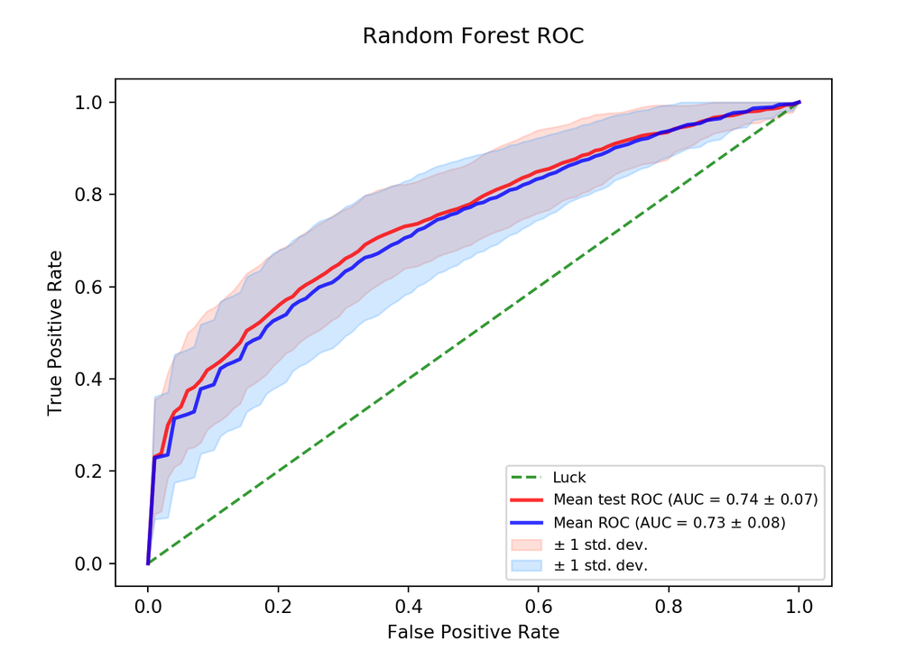

```python
tprs = []
aucs = []
mean_fpr = np.linspace(0, 1, 100)
tprs_test = []
aucs_test = []
mean_fpr_test = np.linspace(0, 1, 100)
RF_plot = plt.figure()
epochs = 50
for epoch in range(epochs):
    x_train, x_test, y_train, y_test = train_test_split(x, y, test_size=0.2, shuffle=True)
    X=x_train.values
    Y=y_train.values
    X_test= x_test.values
    Y_test= y_test.values
    i = 0
    for train, test in cv.split(X,Y):
        probas_ = rfc.fit(X[train], Y[train]).predict_proba(X[test])
    # Compute ROC curve and area the curve
        fpr, tpr, thresholds = roc_curve(Y[test], probas_[:, 1])
        tprs.append(interp(mean_fpr, fpr, tpr))
        tprs[-1][0] = 0.0
        roc_auc = auc(fpr, tpr)
        aucs.append(roc_auc)
        #plt.plot(fpr, tpr, lw=1, alpha=0.3, label='Epoch %d, ROC fold %d (AUC = %0.2f)' % (epoch, i, roc_auc))
        #i += 1
    probas_ = rfc.predict_proba(X_test)
    # Compute ROC curve and area the curve
    fpr_test, tpr_test, thresholds_test = roc_curve(Y_test, probas_[:, 1])
    tprs_test.append(interp(mean_fpr_test, fpr_test, tpr_test))
    tprs_test[-1][0] = 0.0
    roc_auc_test = auc(fpr_test, tpr_test)
    aucs_test.append(roc_auc_test)
plt.plot([0, 1], [0, 1], linestyle='--', color='green', label='Luck', alpha=.8)
mean_tpr_test = np.mean(tprs_test, axis=0)
mean_tpr_test[-1] = 1.0
mean_auc_test = auc(mean_fpr_test, mean_tpr_test)
std_auc_test = np.std(aucs_test)
plt.plot(mean_fpr_test, mean_tpr_test, color='r', label=r'Mean test ROC (AUC = %0.2f $\pm$ %0.2f)' % (mean_auc_test, std_auc_test), lw=2, alpha=.8)
std_tpr_test = np.std(tprs_test, axis=0)
tprs_upper_test = np.minimum(mean_tpr_test + std_tpr_test, 1)
tprs_lower_test = np.maximum(mean_tpr_test - std_tpr_test, 0)
plt.fill_between(mean_fpr_test, tprs_lower_test, tprs_upper_test, color='tomato', alpha=.2, label=r'$\pm$ 1 std. dev.')
mean_tpr = np.mean(tprs, axis=0)
mean_tpr[-1] = 1.0
mean_auc = auc(mean_fpr, mean_tpr)
std_auc = np.std(aucs)
plt.plot(mean_fpr, mean_tpr, color='b', label=r'Mean ROC (AUC = %0.2f $\pm$ %0.2f)' % (mean_auc, std_auc), lw=2, alpha=.8)
std_tpr = np.std(tprs, axis=0)
tprs_upper = np.minimum(mean_tpr + std_tpr, 1)
tprs_lower = np.maximum(mean_tpr - std_tpr, 0)
plt.fill_between(mean_fpr, tprs_lower, tprs_upper, color='dodgerblue', alpha=.2, label=r'$\pm$ 1 std. dev.')
plt.xlim([-0.05, 1.05])
plt.ylim([-0.05, 1.05])
plt.xlabel('False Positive Rate')
plt.ylabel('True Positive Rate')
plt.title('Random Forest ROC\n')
plt.legend(loc="lower right", fontsize=8)
plt.show()
#RF_plot.savefig('results/figures/RF_Baxter.png', dpi=1000)
```

#### Now let’s define a XGBoost model

Previous cross validation step allowed us to choose n_estimators(decision trees), max_depth and learning rate.

```python
clf = xgb.XGBClassifier(base_score=0.5, booster='gbtree', colsample_bylevel=1,
       colsample_bytree=1, gamma=0, learning_rate=0.01, max_delta_step=0,
       max_depth=1, min_child_weight=1, missing=None, n_estimators=250,
       n_jobs=1, nthread=None, objective='binary:logistic', random_state=0,
       reg_alpha=0, reg_lambda=0.1, scale_pos_weight=1, seed=None,
       silent=True, subsample=1)
```

#### Plot ROC curve for XGBoost on training set and predict test set

We split training and test set 80-20%. We further split the training set to 5 to cross-validate in a loop. We predict test set in the same loop. We generate mean AUC for cross-validation with training set upon 50 epochs and mean AUC for test set upon 50 epochs.

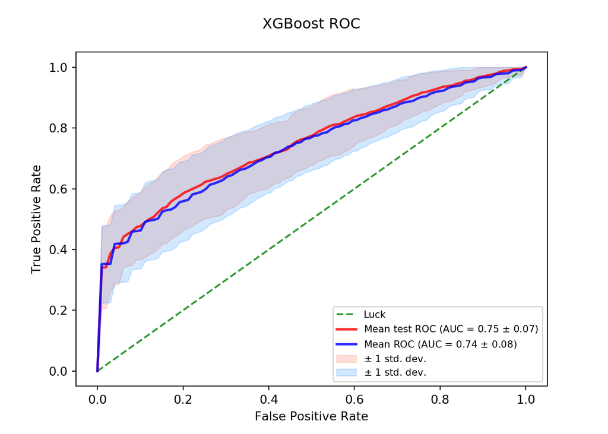

```python
cv = StratifiedKFold(n_splits=5)
tprs = []
aucs = []
mean_fpr = np.linspace(0, 1, 100)
tprs_test = []
aucs_test = []
mean_fpr_test = np.linspace(0, 1, 100)
XGboost_plot = plt.figure()
epochs = 50
for epoch in range(epochs):
    x_train, x_test, y_train, y_test = train_test_split(x, y, test_size=0.2, shuffle=True)
    X=x_train.values
    Y=y_train.values
    X_test= x_test.values
    Y_test= y_test.values
    i = 0
    for train, test in cv.split(X,Y):
        probas_ = clf.fit(X[train], Y[train]).predict_proba(X[test])
    # Compute ROC curve and area the curve
        fpr, tpr, thresholds = roc_curve(Y[test], probas_[:, 1])
        tprs.append(interp(mean_fpr, fpr, tpr))
        tprs[-1][0] = 0.0
        roc_auc = auc(fpr, tpr)
        aucs.append(roc_auc)
        #plt.plot(fpr, tpr, lw=1, alpha=0.3, label='Epoch %d, ROC fold %d (AUC = %0.2f)' % (epoch, i, roc_auc))
        #i += 1
    probas_ = clf.predict_proba(X_test)
    # Compute ROC curve and area the curve
    fpr_test, tpr_test, thresholds_test = roc_curve(Y_test, probas_[:, 1])
    tprs_test.append(interp(mean_fpr_test, fpr_test, tpr_test))
    tprs_test[-1][0] = 0.0
    roc_auc_test = auc(fpr_test, tpr_test)
    aucs_test.append(roc_auc_test)
plt.plot([0, 1], [0, 1], linestyle='--', color='green', label='Luck', alpha=.8)
mean_tpr_test = np.mean(tprs_test, axis=0)
mean_tpr_test[-1] = 1.0
mean_auc_test = auc(mean_fpr_test, mean_tpr_test)
std_auc_test = np.std(aucs_test)
plt.plot(mean_fpr_test, mean_tpr_test, color='r', label=r'Mean test ROC (AUC = %0.2f $\pm$ %0.2f)' % (mean_auc_test, std_auc_test), lw=2, alpha=.8)
std_tpr_test = np.std(tprs_test, axis=0)
tprs_upper_test = np.minimum(mean_tpr_test + std_tpr_test, 1)
tprs_lower_test = np.maximum(mean_tpr_test - std_tpr_test, 0)
plt.fill_between(mean_fpr_test, tprs_lower_test, tprs_upper_test, color='tomato', alpha=.2, label=r'$\pm$ 1 std. dev.')
mean_tpr = np.mean(tprs, axis=0)
mean_tpr[-1] = 1.0
mean_auc = auc(mean_fpr, mean_tpr)
std_auc = np.std(aucs)
plt.plot(mean_fpr, mean_tpr, color='b', label=r'Mean ROC (AUC = %0.2f $\pm$ %0.2f)' % (mean_auc, std_auc), lw=2, alpha=.8)
std_tpr = np.std(tprs, axis=0)
tprs_upper = np.minimum(mean_tpr + std_tpr, 1)
tprs_lower = np.maximum(mean_tpr - std_tpr, 0)
plt.fill_between(mean_fpr, tprs_lower, tprs_upper, color='dodgerblue', alpha=.2, label=r'$\pm$ 1 std. dev.')
plt.xlim([-0.05, 1.05])
plt.ylim([-0.05, 1.05])
plt.xlabel('False Positive Rate')
plt.ylabel('True Positive Rate')
plt.title('XGBoost ROC\n')
plt.legend(loc="lower right", fontsize=8)
plt.show()
#XGboost_plot.savefig('results/figures/XGBoost_Baxter.png', dpi=1000)
```

#### Now let’s define a 1 hidden layer(n=100) Feed Forward Neural Net

PyTorch allows for forward computation. One epoch will mean getting the output values(the way our model defines them), one backward pass where weights in the model are updated and then optimize the hyperparameters for the next epoch.

```python
class Net(nn.Module):
    def __init__(self):
        super(Net, self).__init__()
        self.fc1 = nn.Linear(6920, 100)
        self.fc2 = nn.Linear(100, 2)
    def forward(self, x):
        x = self.fc1(x)
        x = F.dropout(x, p=0.1)
        x = F.relu(x)
        x = self.fc2(x)
        x = F.sigmoid(x)
        return x
net = Net()
## Batch size allows for random sampling of the dataset during training
batch_size = 50
num_epochs = 40
learning_rate = 0.0001
batch_no = 233 // batch_size
# Define Loss function and optimizer function
criterion = nn.CrossEntropyLoss()
optimizer = torch.optim.Adam(net.parameters(), lr=learning_rate)
## Plot ROC for training (with minibatches) and evaluate test sets
pyTorch_plot = plt.figure()
tprs = []
aucs = []
mean_fpr = np.linspace(0, 1, 100)
tprs_test = []
aucs_test = []
mean_fpr_test = np.linspace(0, 1, 100)
for epoch in range(num_epochs):
    x_train, x_test, y_train, y_test = train_test_split(x, y, test_size=0.2, shuffle=True)
    # Mini batch learning
    for i in range(batch_no):
        start = i * batch_size
        end = start + batch_size
        x_var = Variable(torch.FloatTensor(x_train.values[start:end]))
        y_var = Variable(torch.LongTensor(y_train.values[start:end]))
        # Forward + Backward + Optimize
        ypred_var = net(x_var)
        loss =criterion(ypred_var, y_var)
        correct_num = 0
        ## The outputs of the model (ypred_var) are energies for the 10 classes. Higher the energy for a class, the more the network thinks that the image is of the particular class. So, let’s get the index of the highest energy:
        values, labels = torch.max(ypred_var, 1)
        correct_num = np.sum(labels.data.numpy() == y_var.numpy())
        fpr, tpr, thresholds = roc_curve(y_var.numpy(), labels.data.numpy())
        tprs.append(interp(mean_fpr, fpr, tpr))
        tprs[-1][0] = 0.0
        roc_auc = auc(fpr, tpr)
        aucs.append(roc_auc)
        optimizer.zero_grad()
        loss.backward()
        optimizer.step()
        print('Epoch [%d], Loss:%.4f, Accuracy:%.4f' % (epoch, loss.data[0], correct_num/len(labels)))
        #plt.plot(fpr, tpr, lw=1, alpha=0.3, label='ROC fold %d (AUC = %0.2f)' % (epoch, roc_auc))
   #Predict test set and plot mean AUC
    x_var_test = Variable(torch.FloatTensor(x_test.values))
    y_var_test = Variable(torch.LongTensor(y_test.values))
    net.eval()
    ypred_var_test = net(x_var_test)
    correct_num_test = 0
    values_test, labels_test = torch.max(ypred_var_test, 1)
    correct_num_test = np.sum(labels_test.data.numpy() == y_var_test.numpy())
    fpr_test, tpr_test, thresholds_test = roc_curve(y_var_test.numpy(), labels_test.data.numpy())
    tprs_test.append(interp(mean_fpr_test, fpr_test, tpr_test))
    tprs_test[-1][0] = 0.0
    roc_auc_test = auc(fpr_test, tpr_test)
    aucs_test.append(roc_auc_test)
```

```
[Output] Epoch [0], Loss:0.7002, Accuracy:0.4600
[Output] Epoch [0], Loss:0.7694, Accuracy:0.3400
[Output] Epoch [0], Loss:0.7332, Accuracy:0.4400
[Output] Epoch [0], Loss:0.6832, Accuracy:0.3600
[Output] Epoch [1], Loss:0.6823, Accuracy:0.3800
[Output] Epoch [1], Loss:0.7084, Accuracy:0.4400
[Output] Epoch [1], Loss:0.6911, Accuracy:0.5200
[Output] Epoch [1], Loss:0.6920, Accuracy:0.6400
[Output] Epoch [2], Loss:0.6825, Accuracy:0.6400
[Output] Epoch [2], Loss:0.6796, Accuracy:0.5200
[Output] Epoch [2], Loss:0.6868, Accuracy:0.6400
[Output] Epoch [2], Loss:0.6835, Accuracy:0.5000
[Output] Epoch [3], Loss:0.6874, Accuracy:0.5200
[Output] Epoch [3], Loss:0.6741, Accuracy:0.7200
[Output] Epoch [3], Loss:0.6790, Accuracy:0.6200
[Output] Epoch [3], Loss:0.6627, Accuracy:0.5600
[Output] Epoch [4], Loss:0.6701, Accuracy:0.7200
[Output] Epoch [4], Loss:0.6604, Accuracy:0.5800
[Output] Epoch [4], Loss:0.6782, Accuracy:0.4800
[Output] Epoch [4], Loss:0.6464, Accuracy:0.6000
[Output] Epoch [5], Loss:0.6578, Accuracy:0.6000
[Output] Epoch [5], Loss:0.6394, Accuracy:0.5400
[Output] Epoch [5], Loss:0.6477, Accuracy:0.5000
[Output] Epoch [5], Loss:0.6773, Accuracy:0.5000
[Output] Epoch [6], Loss:0.6831, Accuracy:0.4400
[Output] Epoch [6], Loss:0.6431, Accuracy:0.5000
[Output] Epoch [6], Loss:0.6229, Accuracy:0.5200
[Output] Epoch [6], Loss:0.6389, Accuracy:0.5400
[Output] Epoch [7], Loss:0.6422, Accuracy:0.4400
[Output] Epoch [7], Loss:0.6109, Accuracy:0.5600
[Output] Epoch [7], Loss:0.6427, Accuracy:0.5400
[Output] Epoch [7], Loss:0.6532, Accuracy:0.4200
[Output] Epoch [8], Loss:0.6284, Accuracy:0.4400
[Output] Epoch [8], Loss:0.6378, Accuracy:0.5000
[Output] Epoch [8], Loss:0.6299, Accuracy:0.4600
[Output] Epoch [8], Loss:0.6321, Accuracy:0.4600
[Output] Epoch [9], Loss:0.5999, Accuracy:0.6400
[Output] Epoch [9], Loss:0.6001, Accuracy:0.5600
[Output] Epoch [9], Loss:0.6059, Accuracy:0.6000
[Output] Epoch [9], Loss:0.6513, Accuracy:0.5200
```

[output cut: 105 more lines]

```
[Output] Epoch [36], Loss:0.3767, Accuracy:0.9200
[Output] Epoch [36], Loss:0.3382, Accuracy:0.9800
[Output] Epoch [36], Loss:0.3460, Accuracy:0.9200
[Output] Epoch [37], Loss:0.3761, Accuracy:0.8800
[Output] Epoch [37], Loss:0.3605, Accuracy:0.9000
[Output] Epoch [37], Loss:0.3611, Accuracy:0.9000
[Output] Epoch [37], Loss:0.3396, Accuracy:0.9600
[Output] Epoch [38], Loss:0.3680, Accuracy:0.9200
[Output] Epoch [38], Loss:0.3914, Accuracy:0.8000
[Output] Epoch [38], Loss:0.3460, Accuracy:0.9400
[Output] Epoch [38], Loss:0.3631, Accuracy:0.8800
[Output] Epoch [39], Loss:0.3607, Accuracy:0.9000
[Output] Epoch [39], Loss:0.3300, Accuracy:1.0000
[Output] Epoch [39], Loss:0.3388, Accuracy:0.9400
[Output] Epoch [39], Loss:0.3695, Accuracy:0.9200
```

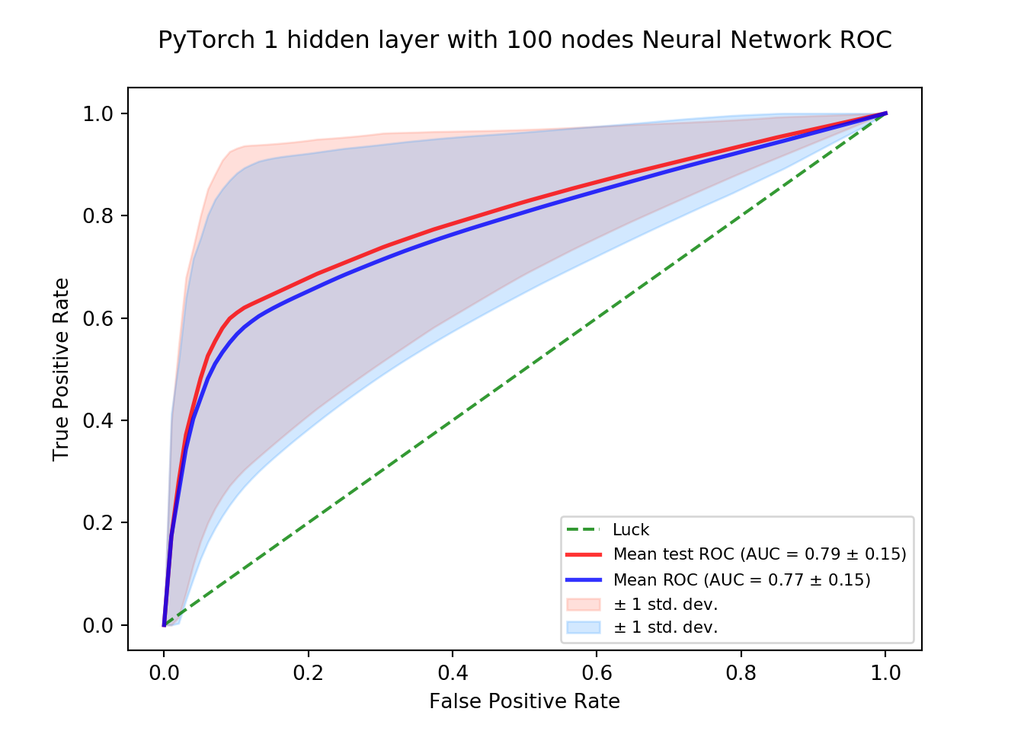

```python
plt.plot([0, 1], [0, 1], linestyle='--', color='green', label='Luck', alpha=.8)
mean_tpr_test = np.mean(tprs_test, axis=0)
mean_tpr_test[-1] = 1.0
mean_auc_test = auc(mean_fpr_test, mean_tpr_test)
std_auc_test = np.std(aucs_test)
plt.plot(mean_fpr_test, mean_tpr_test, color='r', label=r'Mean test ROC (AUC = %0.2f $\pm$ %0.2f)' % (mean_auc_test, std_auc_test), lw=2, alpha=.8)
std_tpr_test = np.std(tprs_test, axis=0)
tprs_upper_test = np.minimum(mean_tpr_test + std_tpr_test, 1)
tprs_lower_test = np.maximum(mean_tpr_test - std_tpr_test, 0)
plt.fill_between(mean_fpr_test, tprs_lower_test, tprs_upper_test, color='tomato', alpha=.2, label=r'$\pm$ 1 std. dev.')
mean_tpr = np.mean(tprs, axis=0)
mean_tpr[-1] = 1.0
mean_auc = auc(mean_fpr, mean_tpr)
std_auc = np.std(aucs)
plt.plot(mean_fpr, mean_tpr, color='b', label=r'Mean ROC (AUC = %0.2f $\pm$ %0.2f)' % (mean_auc, std_auc), lw=2, alpha=.8)
std_tpr = np.std(tprs, axis=0)
tprs_upper = np.minimum(mean_tpr + std_tpr, 1)
tprs_lower = np.maximum(mean_tpr - std_tpr, 0)
plt.fill_between(mean_fpr, tprs_lower, tprs_upper, color='dodgerblue', alpha=.2, label=r'$\pm$ 1 std. dev.')
plt.xlim([-0.05, 1.05])
plt.ylim([-0.05, 1.05])
plt.xlabel('False Positive Rate')
plt.ylabel('True Positive Rate')
plt.title('PyTorch 1 hidden layer with 100 nodes Neural Network ROC\n')
plt.legend(loc="lower right", fontsize=8)
plt.show()
```